# xwMOOC 모형

항공여객 데이터 ARIMA 모형 - `rsample`

xwMOOC

2018-07-05

# 1 항공여객 시계열 데이터 [^1]

시계열계의 `iris` 붓꽃 데이터인 `AirPassenger` 항공여객 데이터를 훈련/시험 데이터로 분할해보자. 항공여객 데이터는 한시대를 풍미한 박스-젠킨스 ARIMA 모형의 우수성을 증명하는 데이터로 자주 인용되고 있다. `datasets` 팩키지에 포함된 `ts` 객체 항공여객 데이터(`AirPassengers`)를 `as_tbl_time()` 함수로 변환시켜 `ggplot`으로 시각화한다.

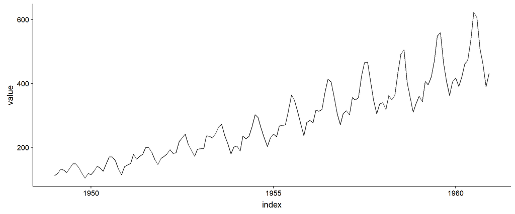

```r
# 0. 환경설정 -----
# Core Tidyverse
library(tidyverse)
library(glue)
library(forcats)

# Time Series
library(timetk)
library(tidyquant)
library(tibbletime)
library(sweep)

# Visualization
library(cowplot)

# Preprocessing
library(recipes)

# Sampling / Accuracy
library(rsample)
library(yardstick)

# Modeling
library(forecast)

# 1. 데이터 -----
## 1.1. 데이터 가져오기 ----
ap_ts  <- datasets::AirPassengers %>%
  tk_tbl() %>%
  mutate(index = as_date(index)) %>%
  as_tbl_time(index = index)

ggplot(ap_ts, aes(x=index, y=value)) +
  geom_line()
```

# 2 시계열 데이터 분할

시계열 데이터를 훈련/시험 데이터로 분할하는 방법은 상관관계를 유지해야 되다는 측면에서 차이가 난다. `rolling_origin()` 함수로 시계열 데이터를 훈련/시험 데이터로 준비한다. 그리고, 시계열 데이터 식별할 수 있도록 훈련데이터와 시험데이터 시작 시점을 알 수 있도록 뽑아내서 티블(tibble)에 추가한다.

```r
## 1.2. rsample 교차검증 데이터 ----
periods_train <- 12 * 2
periods_test  <- 12 * 1
skip_span     <- 11

roll_ap_rs <- rolling_origin(
  ap_ts ,
  initial    = periods_train,
  assess     = periods_test,
  cumulative = FALSE,
  skip       = skip_span
)

# 2. 예측모형 구축 -----
## 2.1. 예측모형 훈련/검증 재표본 살펴보기
get_test_date <- function(x)
  min(assessment(x)$index)

get_train_date <- function(x)
  min(analysis(x)$index)

test_start_date  <- map(roll_ap_rs$splits, get_test_date)
train_start_date <- map(roll_ap_rs$splits, get_train_date)

roll_ap_rs$train_start_date <- do.call("c", train_start_date)
roll_ap_rs$test_start_date  <- do.call("c", test_start_date)

head(roll_ap_rs)
```

```
# A tibble: 6 x 4
  splits       id      train_start_date test_start_date
* <list>       <chr>   <date>           <date>
1 <S3: rsplit> Slice01 1949-01-01       1951-01-01
2 <S3: rsplit> Slice02 1950-01-01       1952-01-01
3 <S3: rsplit> Slice03 1951-01-01       1953-01-01
4 <S3: rsplit> Slice04 1952-01-01       1954-01-01
5 <S3: rsplit> Slice05 1953-01-01       1955-01-01
6 <S3: rsplit> Slice06 1954-01-01       1956-01-01
```

# 3 ARIMA 모형 적합

`fit_arima()` ARIMA 함수를 사용해서 각 시계열 훈련데이터에 적합시킨다. 물론 함수형 프로그래밍 `map()` 함수를 사용한다.

```r
## 2.2. 시계열 분석
### ARIMA 모형 적합
fit_arima <- function(x, ...) {
  x %>%
    analysis() %>%
    tk_ts(start = .$index[[1]] %>% zoo::as.yearmon(),
          freq = 12,
          silent = TRUE) %>%
    auto.arima(...)
}

roll_ap_rs$arima <- map(roll_ap_rs$splits, fit_arima)

roll_ap_rs$arima[[1]]
```

```
Series: .
ARIMA(1,0,1) with non-zero mean

Coefficients:
         ar1     ma1      mean
      0.4137  0.6353  133.3991
s.e.  0.2091  0.1479    6.2032

sigma^2 estimated as 147.9:  log likelihood=-93
AIC=193.99   AICc=196.1   BIC=198.7
```

# 4 ARIMA 모형 내삽/외삽 오차

ARIMA 모형을 적합시키게 되면 내삽오차(interpolation)와 외삽오차(extrapolation)를 각각 계산하여 티블에 저장시킨다.

```r
### ARIMA 모형 내삽오차(interpolation error)
roll_ap_rs$interpolation <- map_dbl(
  roll_ap_rs$arima,
  function(x)
    sw_glance(x)[["MAPE"]]
)

summary(roll_ap_rs$interpolation)
```

```
   Min. 1st Qu.  Median    Mean 3rd Qu.    Max.
  7.054   7.438   7.724   8.054   8.949   9.321
```

```r
### ARIMA 모형 외삽오차(extrapolation error)
get_extrapolate <- function(split, mod) {
  n <- nrow(assessment(split))
  pred_dat <- assessment(split) %>%
    mutate(
      pred = as.vector(forecast(mod, h = n)$mean),
      pct_error = ( value - pred ) / value * 100
    )
  mean(abs(pred_dat$pct_error))
}

roll_ap_rs$extrapolation <-
  map2_dbl(roll_ap_rs$splits, roll_ap_rs$arima, get_extrapolate)

summary(roll_ap_rs$extrapolation)
```

```
   Min. 1st Qu.  Median    Mean 3rd Qu.    Max.
  12.01   13.59   14.34   14.86   15.69   19.77
```

# 5 내삽/외삽 오차 시각화

내삽/외삽 오차를 시각화하여 훈련/검증 각 시계열에 대해서 살펴본다.

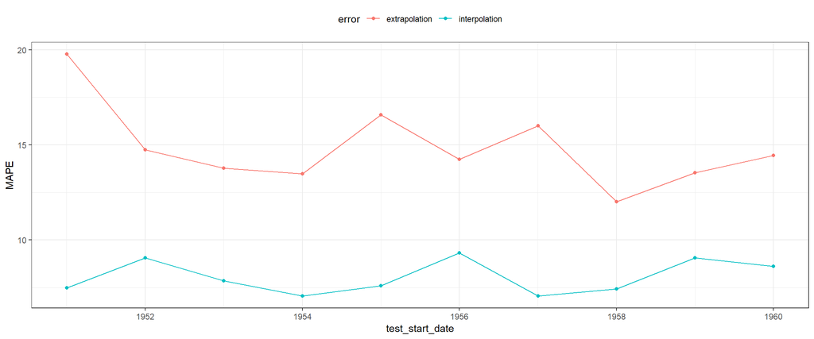

```r
## 2.3. 시계열 모형 성능 시각화

roll_ap_rs %>%
  select(interpolation, extrapolation, test_start_date) %>%
  as.data.frame %>%
  gather(error, MAPE, -test_start_date) %>%
  ggplot(aes(x = test_start_date, y = MAPE, col = error)) +
  geom_point() +
  geom_line() +
  theme_bw() +
  theme(legend.position = "top")
```

[^1]: [rsample - Time Series Analysis Example](https://tidymodels.github.io/rsample/articles/Applications/Time_Series.html)